# City Proximity and Land Cover Analysis for California Wildfires (2020)

2025-03-14

# Motivation

The 2020 California wildfire season was one of the most destructive on record, with over 4 million acres burned across the state. This part of analysis focuses on two critical determinants of wildfire impact:

1. the proximity of fires to populated areas.
2. the types of land cover affected by these fires. These factors are essential for understanding both the human impact and ecological significance of wildfire events.

# City Proximity Analysis

Understanding the spatial relationship between wildfire perimeters and population centers is crucial for several reasons:

- Emergency Response Planning: By quantifying the distance between fires and communities, emergency management can better prioritize resources and evacuation efforts for the most at-risk populations.
- Public Health Implications: Even communities not directly threatened by flames can experience significant health impacts from smoke and air quality degradation, which are influenced by proximity to active fires.
- Urban-Wildland Interface: As California’s development continues to expand into previously wild areas, the interface between human settlements and fire-prone landscapes becomes increasingly important to map and understand.

Our analysis uses geospatial techniques to measure distances between city centroids and fire perimeters, identifying communities within critical distance thresholds (particularly those within 50km of fire boundaries).

```r
#Distance from cities
##########

# Load necessary libraries
# install.packages(c("sf", "terra", "raster", "httr", "jsonlite","FedData"))
library(sf)
library(dplyr)
library(ggplot2)
library(matrixStats)
library(terra)
library(raster)
library(httr)
library(jsonlite)
library(FedData)
```

```r
# Read Fire Data (2020 only)
data <- st_read("~/Desktop/Victoria/DSDM/Term2/Geospatial/Final_Project/California_Fire_Perimeters_(all)/California_Fire_Perimeters_(all).shp")
data <- data %>% filter(YEAR_ == 2020)

# Read California State Boundary
US_States <- st_read("~/Desktop/Victoria/DSDM/Term2/Geospatial/Final_Project/ne_110m_admin_1_states/ne_110m_admin_1_states_provinces.shp")
US_States_simple <- US_States %>% dplyr::select(name, postal, latitude, longitude, geometry)
CA <- US_States_simple %>% filter(postal == "CA")

# Read the “Places” shapefile
# Loading this to get info about cities
places <- st_read("~/Desktop/Victoria/DSDM/Term2/Geospatial/Final_Project/tl_2020_06_place/tl_2020_06_place.shp")
colnames(places)
```

```
##  [1] "STATEFP"  "PLACEFP"  "PLACENS"  "GEOID"    "NAME"     "NAMELSAD"
##  [7] "LSAD"     "CLASSFP"  "PCICBSA"  "PCINECTA" "MTFCC"    "FUNCSTAT"
## [13] "ALAND"    "AWATER"   "INTPTLAT" "INTPTLON" "geometry"
```

```r
head(places)
```

```
## Simple feature collection with 6 features and 16 fields
## Geometry type: MULTIPOLYGON
## Dimension:     XY
## Bounding box:  xmin: -120.6741 ymin: 33.62517 xmax: -117.6746 ymax: 40.45356
## Geodetic CRS:  NAD83
##   STATEFP PLACEFP  PLACENS   GEOID         NAME          NAMELSAD LSAD CLASSFP
## 1      06   77364 02412017 0677364   Susanville   Susanville city   25      C1
## 2      06   02000 02409704 0602000      Anaheim      Anaheim city   25      C1
## 3      06   16532 02410239 0616532   Costa Mesa   Costa Mesa city   25      C1
## 4      06   17750 02410282 0617750      Cypress      Cypress city   25      C1
## 5      06   28000 02410556 0628000    Fullerton    Fullerton city   25      C1
## 6      06   29000 02410568 0629000 Garden Grove Garden Grove city   25      C1
##   PCICBSA PCINECTA MTFCC FUNCSTAT     ALAND  AWATER    INTPTLAT     INTPTLON
## 1       Y        N G4110        A  20507839  218688 +40.4336740 -120.6283062
## 2       Y        N G4110        A 130206498 1567025 +33.8555018 -117.7586572
## 3       Y        N G4110        A  40937896   24554 +33.6659055 -117.9123358
## 4       N        N G4110        A  17127354   22003 +33.8184768 -118.0383074
## 5       N        N G4110        A  58065841   32825 +33.8857156 -117.9280247
## 6       N        N G4110        A  46506034   45894 +33.7787816 -117.9604719
##                         geometry
## 1 MULTIPOLYGON (((-120.5261 4...
## 2 MULTIPOLYGON (((-118.0175 3...
## 3 MULTIPOLYGON (((-117.9546 3...
## 4 MULTIPOLYGON (((-118.0633 3...
## 5 MULTIPOLYGON (((-117.9854 3...
## 6 MULTIPOLYGON (((-118.0429 3...
```

```r
# Reproject all layers to EPSG:3310 at the start
data_3310 <- st_transform(data, 3310)
CA_3310 <- st_transform(CA, 3310)
places_ca_centroids_3310 <- st_centroid(st_transform(places, 3310))

# Combine all fire polygons into one and compute centroid
fire_union_3310 <- st_union(data_3310)
fire_union_centroid_3310 <- st_centroid(fire_union_3310)
```

### Distance from each city centroid to the fire boundary and union centroid

```r
# Distance from each city centroid to the fire boundary and union centroid
places_ca_centroids_3310$dist_to_fire_boundary <- st_distance(places_ca_centroids_3310, fire_union_3310)
places_ca_centroids_3310$dist_to_fire_union_centroid <- st_distance(places_ca_centroids_3310, fire_union_centroid_3310)

# Compute centroids of individual fires and their distances to cities
fire_centroids_3310 <- st_centroid(data_3310)
city_fire_matrix <- st_distance(places_ca_centroids_3310, fire_centroids_3310)

# Extract the nearest fire centroid distance per city
places_ca_centroids_3310$dist_to_nearest_fire_centroid <- rowMins(city_fire_matrix)
```

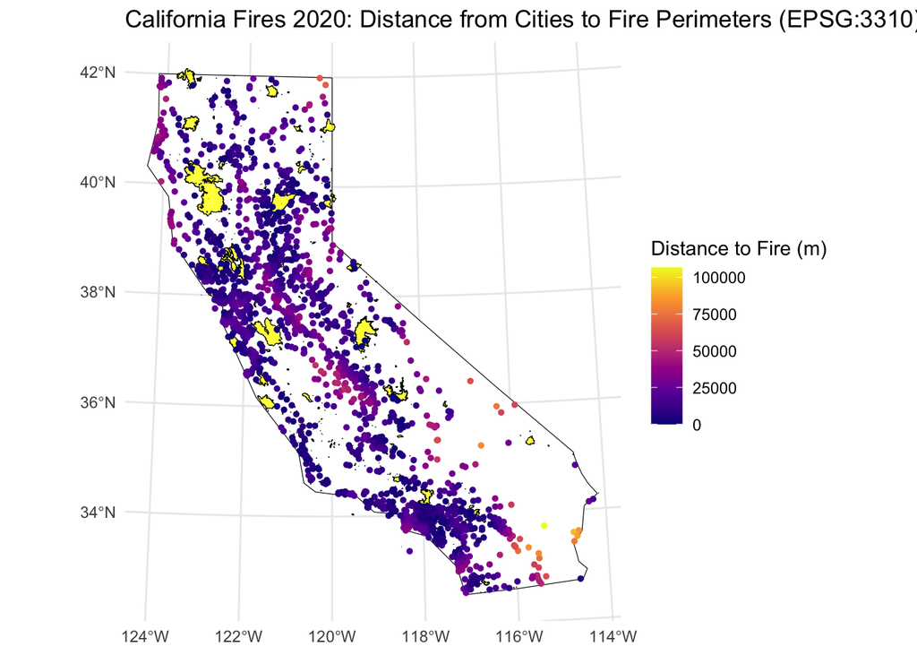

```r
ggplot() +
  # California boundary
  geom_sf(data = CA_3310, fill = "white", color = "black") +

  # Fire polygons
  geom_sf(data = data_3310, fill = "yellow", alpha = 0.8, color = "black") +

  # City centroids, colored by distance to boundary
  geom_sf(
    data = places_ca_centroids_3310,
    aes(color = as.numeric(dist_to_fire_boundary)),
    size = 1
  ) +

  scale_color_viridis_c(option = "plasma") +
  theme_minimal() +
  labs(
    color = "Distance to Fire (m)",
    title = "California Fires 2020: Distance from Cities to Fire Perimeters (EPSG:3310)"
  )
```

This map illustrates the proximity of California cities to fire perimeters during the 2020 wildfire season. Each dot represents a population center, with colors indicating distance to the nearest fire - dark blue/purple dots show cities very close to fire boundaries (under 25,000 meters), while yellow dots represent locations around 100,000 meters from fires.

### Focusing on Close Proximity - 50 Kilometers

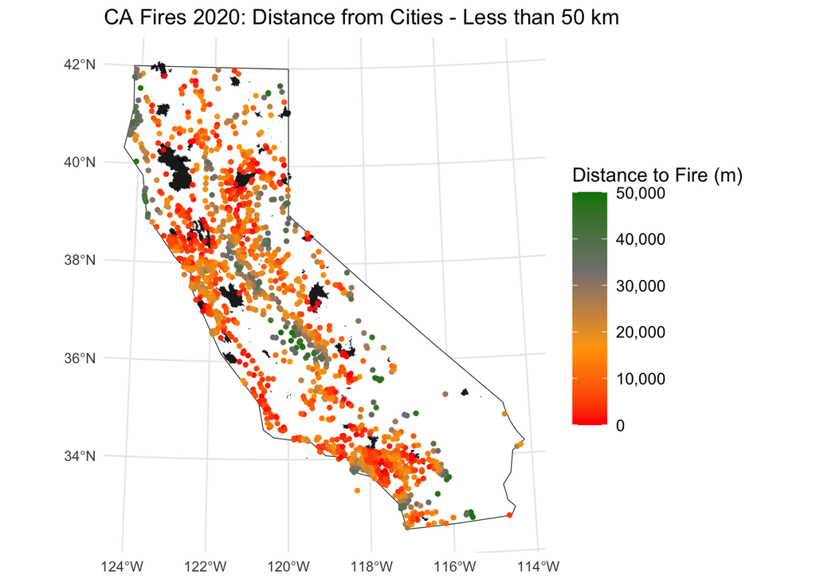

```r
#### Fire Proximity - Filter 50km

# 1. Convert distance units to numeric (removing "units" class):
places_ca_centroids_3310$dist_num <- as.numeric(places_ca_centroids_3310$dist_to_fire_boundary)

# 2. Filter for distances less than 50 km (50,000 meters):
cities_close <- places_ca_centroids_3310 %>%
  filter(dist_num <= 50000)

ggplot() +
  geom_sf(data = CA_3310, fill = "white", color = "black") +
  geom_sf(data = data_3310, fill = "black", alpha = 0.9, color = NA) +
  geom_sf(
    data = cities_close,
    aes(color = as.numeric(dist_to_fire_boundary)),
    size = 1
  ) +
  scale_color_gradientn(
  colors = c("#FF0000", "#FFA500", "#808080", "#008000"),
  limits = c(0, 50000),  # Explicitly set the range
  breaks = c(0, 10000, 20000, 30000, 40000, 50000),
  labels = c("0", "10,000", "20,000", "30,000", "40,000", "50,000")
  ) +
  guides(
    # Make the colorbar bigger/taller, with some padding
    color = guide_colorbar(
      barwidth = 1.5,    # width of the bar in "plot" units
      barheight = 10,    # height of the bar in "plot" units
      title.position = "top"  # puts the legend title on top
    )
  ) +
  theme_minimal() +
  theme(
    legend.title = element_text(size = 12),
    legend.text  = element_text(size = 10)
  ) +
  labs(
    color = "Distance to Fire (m)",
    title = "CA Fires 2020: Distance from Cities - Less than 50 km"
  )
```

This map focuses specifically on California cities within 50 kilometers of fire perimeters. The color gradient ranges from bright red (0 km, directly at the fire boundary) through orange (around 10-20 km) to grayish-green (40-50 km). The 50 km threshold is particularly interesting because it represents a *critical emergency management boundary*. At this distance:

- Communities have minimal *evacuation time* if fire behavior changes rapidly
- *Air quality* impacts become significant for sensitive populations
- *Local resources and infrastructure* may be strained by nearby fire response
- It represents approximately a 30-45 minute drive time, a realistic evacuation zone

What’s striking in this visualization is how many populated areas fall within this high-risk zone. The map reveals dense clusters of red and orange dots (cities within 0-20 km of fires) throughout Central California coastal area such as San Francisco Bay Area and along the Gold Country, while the southern coastal regions also show significant vulnerability. By eliminating cities beyond the 50 km threshold, this map effectively highlights the *communities most directly threatened* by California’s devastating 2020 fire season, showing the widespread nature of immediate fire risk across the state.

### Ranking of the cities at highest risk in 2020

Top 20 closest cities to fire boundaries

```r
# Ensure the distance column is numeric
places_ca_centroids_3310 <- places_ca_centroids_3310 %>%
  mutate(dist_num = as.numeric(dist_to_fire_boundary))

# Filter cities that are within 50 km (i.e., less than 50,000 m)
cities_50 <- places_ca_centroids_3310 %>%
  filter(dist_num < 50000) %>%   # 50 km threshold
  arrange(dist_num)               # Rank in ascending order (closest first)

# Extract a list with city names, distances, and coordinates
cities_list <- dplyr::select(st_drop_geometry(cities_50), NAME, dist_num)

head(cities_list,20)
```

```
##                NAME  dist_num
## 1       Berry Creek   0.00000
## 2         Big Creek   0.00000
## 3        Bonny Doon   0.00000
## 4       Cedar Slope   0.00000
## 5         Deer Park   0.00000
## 6        Forbestown   0.00000
## 7        Happy Camp   0.00000
## 8          Loma Mar   0.00000
## 9  Moskowite Corner   0.00000
## 10              Ono   0.00000
## 11             Ruth   0.00000
## 12    Sequoia Crest   0.00000
## 13      Shaver Lake   0.00000
## 14  Williams Canyon   0.00000
## 15         Modjeska  29.49649
## 16    Boulder Creek  53.50720
## 17         Monrovia  57.69122
## 18        Pierpoint  58.12320
## 19        Brookdale  83.68816
## 20           Walker 104.80624
```

First 14 cities actually were at the epicenter of the wildfires;

# Population-Weighted Risk Analysis for California Wildfires

Population-Weighted Risk Analysis for California Wildfires is essential because it provides a *more accurate representation of human impact than raw geographical proximity* alone. By accounting for both a community’s distance from fires and its population size, this approach highlights areas where large numbers of people are endangered, not just geographical points on a map.

```r
# This part extends our existing analysis to include population weighting

# Check if the places shapefile has population data
if("POP10" %in% colnames(places) || "POPULATION" %in% colnames(places)) {
  # If population field already exists, use it
  pop_field <- ifelse("POP10" %in% colnames(places), "POP10", "POPULATION")

  # Join population to your existing centroids dataframe
  places_ca_centroids_3310 <- places_ca_centroids_3310 %>%
    left_join(st_drop_geometry(places) %>%
              dplyr::select(GEOID, NAME, !!sym(pop_field)),
              by = c("GEOID"))

  # Rename the population field to be consistent
  places_ca_centroids_3310 <- places_ca_centroids_3310 %>%
    rename(Population = !!sym(pop_field))
} else {
  # If no population data is available, we need to get it from Census API
  # or another source. This example uses the tidycensus package.

  # Install if needed
  if(!require(tidycensus)) {
    install.packages("tidycensus")
    library(tidycensus)
  }

  # You'll need a Census API key - get one at https://api.census.gov/data/key_signup.html
  # census_api_key("YOUR_API_KEY")

  # Get population data for places in California
  ca_places_pop <- get_decennial(
    geography = "place",
    variables = "P1_001N", # Total population
    state = "CA",
    year = 2020,
    geometry = FALSE
  )

  # Clean up the data
  ca_places_pop <- ca_places_pop %>%
    rename(Population = value) %>%
    dplyr::select(GEOID, NAME, Population)

  # Join to your centroids
  places_ca_centroids_3310 <- places_ca_centroids_3310 %>%
    left_join(ca_places_pop, by = c("GEOID"))
}
```

```r
########################################################
# Calculate risk categories based on distance and population
########################################################

# Add risk categories based on distance
places_ca_centroids_3310 <- places_ca_centroids_3310 %>%
  mutate(
    # Distance in km for readability
    distance_km = dist_num / 1000,

    # Risk category based on distance
    risk_category = case_when(
      distance_km <= 10 ~ "Extreme",
      distance_km <= 20 ~ "High",
      distance_km <= 35 ~ "Moderate",
      distance_km <= 50 ~ "Low",
      TRUE ~ "Minimal"
    ),

    # Convert risk category to numeric score for calculations
    risk_score = case_when(
      risk_category == "Extreme" ~ 5,
      risk_category == "High" ~ 4,
      risk_category == "Moderate" ~ 3,
      risk_category == "Low" ~ 2,
      TRUE ~ 1
    )
  )

# Calculate population-weighted risk metrics
places_ca_centroids_3310 <- places_ca_centroids_3310 %>%
  mutate(
    # Population at risk (simple metric)
    population_at_risk = ifelse(distance_km <= 50, Population, 0),

    # Population risk score (weighted by both population size and risk level)
    population_risk_score = Population * risk_score,

    # Risk index (normalized score between 0-100)
    risk_index = population_risk_score / max(population_risk_score, na.rm = TRUE) * 100
  )
```

```r
########################################################
# Create a summary table of highest-risk cities
########################################################
high_risk_cities <- places_ca_centroids_3310 %>%
  arrange(desc(risk_index)) %>%
  head(20) %>%
  st_drop_geometry() %>%
  dplyr::select(
    NAME.x,               # The city name is in NAME.x
    Population,
    distance_km,
    risk_category,
    population_at_risk,
    risk_index
  ) %>%
  # Rename NAME.x to City for clarity
  rename(City = NAME.x)

# Print the table
print(high_risk_cities[, c("City", "Population", "distance_km", "risk_category")])
```

```
##              City Population distance_km risk_category
## 1     Los Angeles    3898747   16.110525          High
## 2       San Diego    1386932   21.395025      Moderate
## 3        San Jose    1013240   12.712847          High
## 4   San Francisco     873965   23.711741      Moderate
## 5      Sacramento     524943   18.669549          High
## 6         Oakland     440646   19.682166          High
## 7          Fresno     542107   27.742521      Moderate
## 8     Bakersfield     403455   12.008250          High
## 9          Irvine     307670    3.540512       Extreme
## 10     Long Beach     466742   26.737928      Moderate
## 11        Anaheim     346824   10.755020          High
## 12      Riverside     314998   13.509335          High
## 13      Santa Ana     310227   11.963810          High
## 14  Santa Clarita     228673    4.235302       Extreme
## 15 San Bernardino     222101    9.787156       Extreme
## 16    Chula Vista     275487   15.958549          High
## 17        Fontana     208393    9.272581       Extreme
## 18         Oxnard     202063    3.847839       Extreme
## 19        Fremont     230504   11.136719          High
## 20     Santa Rosa     178127    4.366890       Extreme
```

```r
# Save the table for later use
# write.csv(high_risk_cities, "high_risk_cities_2020.csv", row.names = FALSE)
```

We create a multi-faceted fire risk assessment by incorporating both proximity and population into our metrics. Mathematically, we first convert categorical risk levels into numerical scores (Extreme=5, High=4, Moderate=3, Low=2, Minimal=1) based on distance thresholds. We then calculate a population risk score using the formula:

*Population Risk Score = Population × Risk Score*

This multiplication is mathematically significant because it creates a composite metric where both factors must be substantial to yield a high result. A small town very close to fires or a large city moderately far from fires might have similar scores, reflecting their *comparable overall risk profiles despite different characteristics*.

We further normalize this into a 0-100 risk index using:

Risk Index = (Population Risk Score ÷ Maximum Population Risk Score) × 100

This mathematical transformation maintains the relative relationships between cities while creating an intuitive scale. We believe this weighting approach is important because it avoids the mathematical pitfalls of treating all locations within the buffer zone equally, instead creating a gradient that accurately represents the combined threat of fire proximity and potential human impact.

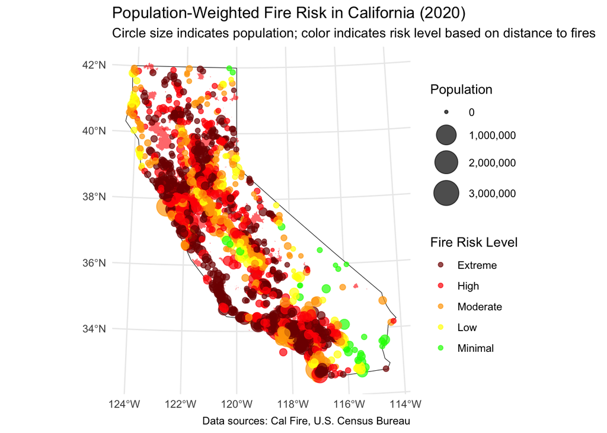

```r
########################################################
# Visualize population-weighted fire risk
########################################################
# Before creating the plot, convert risk_category to an ordered factor
places_ca_centroids_3310 <- places_ca_centroids_3310 %>%
  mutate(
    risk_category = factor(
      risk_category,
      levels = c("Extreme", "High", "Moderate", "Low", "Minimal"),
      ordered = TRUE
    )
  )
# Create a map showing cities with circle size proportional to population and color by risk
ggplot() +
  # California boundary
  geom_sf(data = CA_3310, fill = "white", color = "black") +

  # Fire polygons
  geom_sf(data = data_3310, fill = "red", alpha = 0.6, color = NA) +

  # City points with size based on population and color based on risk
  geom_sf(
    data = places_ca_centroids_3310 %>% filter(!is.na(Population)),
    aes(
      color = risk_category,
      size = Population
    ),
    alpha = 0.7
  ) +

  # Scale settings
  scale_color_manual(
    values = c("Extreme" = "#7F0000", "High" = "#FF0000",
               "Moderate" = "#FFA500", "Low" = "#FFFF00", "Minimal" = "#00FF00"),
    name = "Fire Risk Level"
  ) +
  scale_size_continuous(
  name = "Population",
  range = c(1, 10),  # Doubled the size range from (0.5, 5) to (1, 10)
  labels = scales::comma,
  trans = "sqrt"     # Using a square root transformation to help with readability
  ) +

  # Map styling
  theme_minimal() +
  labs(
    title = "Population-Weighted Fire Risk in California (2020)",
    subtitle = "Circle size indicates population; color indicates risk level based on distance to fires",
    caption = "Data sources: Cal Fire, U.S. Census Bureau"
  )
```

The map reveals a concerning pattern where many heavily populated areas (represented by larger circles) fall within extreme or high-risk zones (dark red and red colors).

What makes this visualization particularly valuable is how *it combines two critical factors - population size and proximity to fires* - to identify communities where the most people faced the highest danger. This approach highlights areas where emergency resources might have been most needed, rather than treating all locations within buffer zones equally. The prevalence of large circles in red and dark red zones suggests that a substantial portion of California’s population lived under significant wildfire threat during this period.

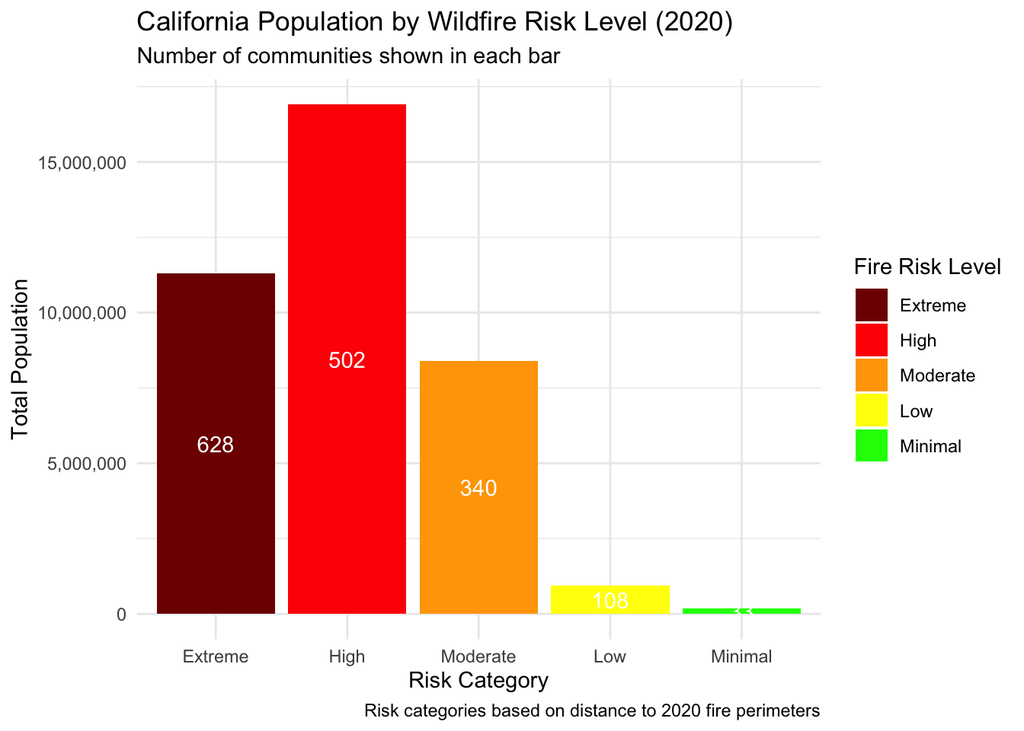

```r
########################################################
# Create a bar chart of population at risk by category
########################################################

# Summarize population at risk by risk category
risk_summary <- places_ca_centroids_3310 %>%
  st_drop_geometry() %>%
  group_by(risk_category) %>%
  summarize(
    total_population = sum(Population, na.rm = TRUE),
    cities_count = n()
  ) %>%
  arrange(factor(risk_category, levels = c("Extreme", "High", "Moderate", "Low", "Minimal")))

# Plot the summary
ggplot(risk_summary, aes(x = factor(risk_category,
                                    levels = c("Extreme", "High", "Moderate", "Low", "Minimal")),
                         y = total_population)) +
  geom_bar(stat = "identity", aes(fill = factor(risk_category))) +
  geom_text(aes(label = paste0(cities_count)),
            position = position_stack(vjust = 0.5), color = "white") +
  scale_fill_manual(
    values = c("Extreme" = "#7F0000", "High" = "#FF0000",
               "Moderate" = "#FFA500", "Low" = "#FFFF00", "Minimal" = "#00FF00"),
    name = "Fire Risk Level"
  ) +
  scale_y_continuous(labels = scales::comma) +
  theme_minimal() +
  labs(
    title = "California Population by Wildfire Risk Level (2020)",
    subtitle = "Number of communities shown in each bar",
    x = "Risk Category",
    y = "Total Population",
    caption = "Risk categories based on distance to 2020 fire perimeters"
  ) +
  theme(axis.text.x = element_text(angle = 0))
```

*Note that* “places” in TIGER/Line shapefiles extends well beyond just incorporated cities. The dataset includes:

- incorporated municipalities (cities, towns),
- Census Designated Places (CDPs) which are unincorporated communities with defined boundaries,
- various smaller settlements that have distinct geographic identities recognized by the Census Bureau

While California has 482 incorporated cities, it has over 1,000 additional Census Designated Places, bringing the total close to the number we’re seeing. This comprehensive inclusion actually strengthens our analysis by providing a more complete picture of population exposure to wildfire risk across all types of human settlements in California, not just major cities.

# Land Cover Type Analysis

The second component examines the relationship between land cover types and fire perimeters, which helps illuminate:

- Fuel Availability: Different vegetation types (forests, shrublands, grasslands) have varying combustibility and fuel characteristics that influence fire behavior.
- Development Patterns: By distinguishing between natural and developed areas affected by fires, we can better understand the human-wildfire relationship in California.
- Ecological Impact Assessment: Identifying which ecosystem types were most affected provides insight into potential ecological consequences and recovery trajectories.

Using the National Land Cover Database (NLCD), our analysis categorizes and quantifies the types of land affected by the 2020 fires, with special attention to the distribution between developed (urban/populated) versus natural/other land covers.

```r
#########################################
# NLCD and Fire Perimeter Data Processing
#########################################

# Load NLCD raster
nlcd_raster <- rast("/Users/macbookpro/Desktop/Victoria/DSDM/Term2/Geospatial/Final_Project/Annual_NLCD_LndCov_2020_CU_C1V0.tif")

# Load California boundary and reproject to match raster CRS
CA <- st_read("~/Desktop/Victoria/DSDM/Term2/Geospatial/Final_Project/ne_110m_admin_1_states/ne_110m_admin_1_states_provinces.shp") %>%
  filter(postal == "CA") %>%
  st_transform(crs(nlcd_raster))
# Convert California boundary to terra format and crop raster
nlcd_ca <- crop(nlcd_raster, vect(CA), mask = TRUE)
```

[output not shown]

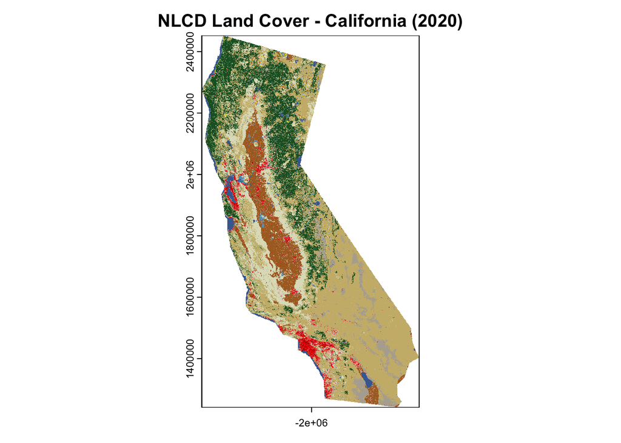

```r
# Visualize cropped raster
plot(nlcd_ca, main = "NLCD Land Cover - California (2020)")
```

```r
#Save cropped raster
writeRaster(nlcd_ca, "NLCD_2020_California.tif", overwrite = TRUE)
```

```
## |---------|---------|---------|---------|=========================================
```

```r
# Load California Land Cover Raster
nlcd_ca <- rast("/Users/macbookpro/NLCD_2020_California.tif")

# Load and clean 2020 fire perimeters, ensuring CRS consistency
fire_perimeters <- st_read("~/Desktop/Victoria/DSDM/Term2/Geospatial/Final_Project/California_Fire_Perimeters_(all)/California_Fire_Perimeters_(all).shp") %>%
  filter(YEAR_ == 2020) %>%
  st_make_valid() %>%
  filter(!st_is_empty(.)) %>%
  st_transform(crs(nlcd_raster))
# Convert fire perimeters to terra vector format
fire_vect <- vect(fire_perimeters)

# Extract land cover data intersecting fires
landcover_fire_extract <- terra::extract(nlcd_ca, fire_vect)

# Convert extracted data to a dataframe and rename columns
landcover_fire_data <- data.frame(landcover_fire_extract)
colnames(landcover_fire_data) <- c("ID", "Land_Cover_Type")

# Summarize extracted land cover data
landcover_summary <- landcover_fire_data %>%
  group_by(Land_Cover_Type) %>%
  summarise(Count = n()) %>%
  arrange(desc(Count))

print(landcover_summary)
```

```
## # A tibble: 16 × 2
##    Land_Cover_Type   Count
##              <int>   <int>
##  1              52 6998187
##  2              42 6824835
##  3              71 3970934
##  4              NA  369912
##  5              43  345179
##  6              21  231006
##  7              41  104816
##  8              22   80187
##  9              90   47870
## 10              11   17731
## 11              95   16092
## 12              31   11987
## 13              82    9030
## 14              81    6181
## 15              23    5894
## 16              24     165
```

```r
# # Convert raster to dataframe for plotting
# nlcd_df <- as.data.frame(nlcd_ca, xy = TRUE, cells = TRUE)
# colnames(nlcd_df) <- c("x", "y", "Land_Cover_Type")
```

```r
########################################
# NLCD Raster Processing and Conversion
########################################

# Reduce raster resolution
nlcd_ca_resampled <- aggregate(nlcd_ca, fact=10, fun=modal)  # Increase `fact` if necessary

# Convert to dataframe
nlcd_df <- as.data.frame(nlcd_ca_resampled, xy = TRUE, cells = TRUE)
colnames(nlcd_df) <- c("x", "y", "Land_Cover_Type")

# Check raster categories before conversion
print(unique(values(nlcd_ca_resampled)))
```

```
##       Annual_NLCD_LndCov_2020_CU_C1V0
##  [1,]                              NA
##  [2,]                              22
##  [3,]                              43
##  [4,]                              11
##  [5,]                              81
##  [6,]                              42
##  [7,]                              41
##  [8,]                              52
##  [9,]                              71
## [10,]                              31
## [11,]                              21
## [12,]                              23
## [13,]                              90
## [14,]                              95
## [15,]                              82
## [16,]                              24
## [17,]                              12
```

```r
# Convert raster to polygon while preserving values
nlcd_poly <- as.polygons(nlcd_ca_resampled, dissolve = TRUE) %>%
  st_as_sf()

# Rename the raster value column (which currently has the raster filename)
colnames(nlcd_poly)[colnames(nlcd_poly) == "Annual_NLCD_LndCov_2020_CU_C1V0"] <- "Land_Cover_Type"

# Ensure column exists
if (!"Land_Cover_Type" %in% colnames(nlcd_poly)) {
  stop("Land_Cover_Type column is missing in nlcd_poly. Check raster attributes.")
}
```

```r
# Define land cover type labels correctly
land_cover_labels <- data.frame(
  Land_Cover_Type = c(11, 12, 21, 22, 23, 24, 31, 41, 42, 43, 52, 71, 81, 82, 90, 95),
  Land_Cover_Name = c("Open Water", "Perennial Ice/Snow", "Developed, Open Space",
                      "Developed, Low Intensity", "Developed, Medium Intensity",
                      "Developed, High Intensity", "Barren Land",
                      "Deciduous Forest", "Evergreen Forest", "Mixed Forest",
                      "Shrub/Scrub", "Grassland/Herbaceous", "Pasture/Hay",
                      "Cultivated Crops", "Woody Wetlands",
                      "Emergent Herbaceous Wetlands")
)
```

```r
# Convert Land_Cover_Type to numeric for proper merging
nlcd_poly$Land_Cover_Type <- as.numeric(nlcd_poly$Land_Cover_Type)

# Merge with land cover labels
nlcd_poly <- left_join(nlcd_poly, land_cover_labels, by = "Land_Cover_Type")

##
#Check here if label naming works
nlcd_poly
```

```
## Simple feature collection with 16 features and 2 fields
## Geometry type: MULTIPOLYGON
## Dimension:     XY
## Bounding box:  xmin: -2356875 ymin: 1240875 xmax: -1650075 ymax: 2452575
## Projected CRS: AEA        WGS84
## First 10 features:
##    Land_Cover_Type             Land_Cover_Name                       geometry
## 1               11                  Open Water MULTIPOLYGON (((-2287275 24...
## 2               12          Perennial Ice/Snow MULTIPOLYGON (((-2145975 23...
## 3               21       Developed, Open Space MULTIPOLYGON (((-2288175 24...
## 4               22    Developed, Low Intensity MULTIPOLYGON (((-2286975 24...
## 5               23 Developed, Medium Intensity MULTIPOLYGON (((-2287875 24...
## 6               24   Developed, High Intensity MULTIPOLYGON (((-2286975 24...
## 7               31                 Barren Land MULTIPOLYGON (((-2287875 24...
## 8               41            Deciduous Forest MULTIPOLYGON (((-2285475 24...
## 9               42            Evergreen Forest MULTIPOLYGON (((-2286375 24...
## 10              43                Mixed Forest MULTIPOLYGON (((-2286675 24...
```

```r
##

# Categorize land use for Developed vs. Natural/Other
nlcd_poly <- nlcd_poly %>%
  mutate(
    Land_Use_Category = ifelse(Land_Cover_Type %in% c(21,22,23,24),
                               "Developed (Urban/Populated)",
                               "Natural / Other")
  )

# Check if all labels joined correctly
if (!"Land_Cover_Name" %in% colnames(nlcd_poly)) {
  stop("Land_Cover_Name column is missing after merging labels.")
}
```

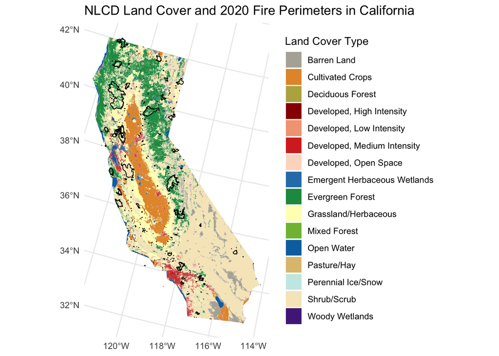

```r
# # Plot using vectorized raster
# ggplot() +
#   geom_sf(data = nlcd_poly, aes(fill = factor(Land_Cover_Name)), color = NA) +
#   geom_sf(data = st_transform(fire_perimeters, crs(nlcd_ca)), fill = NA, color = "black", linewidth = 0.3) +
#   labs(title = "NLCD Land Cover and 2020 Fire Perimeters in California",
#        fill = "Land Cover Type") +
#   theme_minimal()
# Plot with improved color distinction
ggplot() +
  geom_sf(data = nlcd_poly, aes(fill = factor(Land_Cover_Name)), color = NA) +
  geom_sf(data = st_transform(fire_perimeters, crs(nlcd_ca)), fill = NA, color = "black", linewidth = 0.3) +
  scale_fill_manual(values = c(
    "Barren Land" = "#b3afa4",               # Gray-tan for Barren Land
    "Cultivated Crops" = "#e49635",          # Orange
    "Deciduous Forest" = "#b8af4f",          # Olive-gold
    "Developed, High Intensity" = "#990000",  # Dark red
    "Developed, Low Intensity" = "#f2a582",   # Light orange-pink
    "Developed, Medium Intensity" = "#d73027", # Medium red
    "Developed, Open Space" = "#fddbc7",      # Very light pink
    "Emergent Herbaceous Wetlands" = "#2c7fb8", # Blue
    "Evergreen Forest" = "#1a9850",           # Deep green
    "Grassland/Herbaceous" = "#ffffbf",       # Light yellow
    "Mixed Forest" = "#7fbc41",               # Light green
    "Open Water" = "#0571b0",                 # Deep blue
    "Pasture/Hay" = "#dfc27d",                # Tan
    "Perennial Ice/Snow" = "#c7eae5",         # Very light blue
    "Shrub/Scrub" = "#f6e8c3",                # Light tan
    "Woody Wetlands" = "#542788"              # Purple for Woody Wetlands
  )) +
  labs(title = "NLCD Land Cover and 2020 Fire Perimeters in California",
       fill = "Land Cover Type") +
  theme_minimal()
```

Eastern California is dominated by shrub/scrub landscapes (cream color), while the Central Valley features a distinct band of cultivated cropland (orange). Urban development (red shades) is primarily concentrated along the southern coast, notably in the Los Angeles and San Diego regions. This visualization demonstrates how fires disproportionately affected forested regions in northern California and the Sierra Nevada range, while the central agricultural valley and eastern deserts experienced fewer fire events.

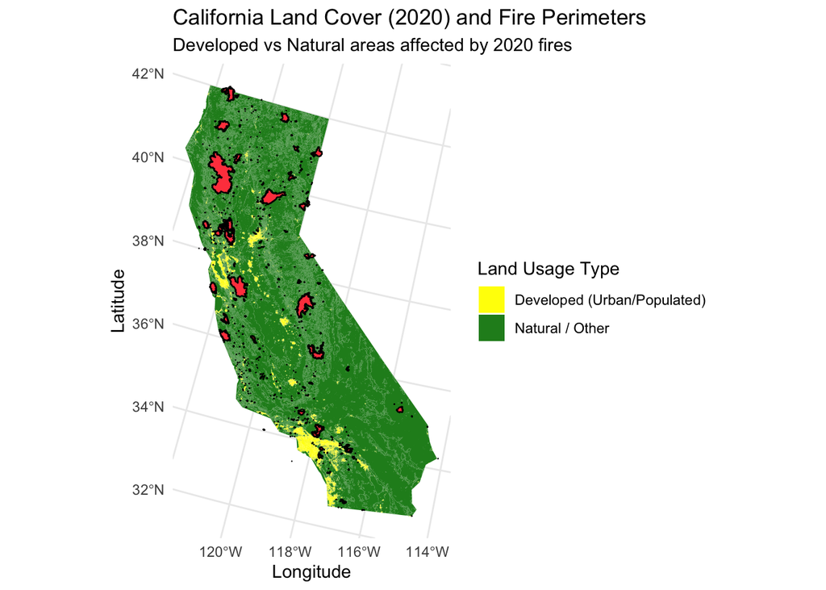

```r
# Plot with categorized land usage
ggplot() +
  geom_sf(data = nlcd_poly, aes(fill = Land_Use_Category), color = NA) +
  geom_sf(data = fire_perimeters, fill = "#FF474C", color = "black", linewidth = 0.4) +
  scale_fill_manual(values=c("yellow", "forestgreen"), name="Land Usage Type") +
  labs(title = "California Land Cover (2020) and Fire Perimeters",
       subtitle = "Developed vs Natural areas affected by 2020 fires",
       x = "Longitude", y = "Latitude") +
  theme_minimal()
```

# Findings

This part analyzed the relationship between California’s 2020 wildfire perimeters and populated areas, creating a comprehensive *assessment of community risk exposure*. Through multiple visualizations, we explored how proximity to fires affected different communities and examined the geographical patterns of wildfire risk across diverse landscapes.

## Key components included:

- Mapping fire proximity zones with distance thresholds (0-50km)
- Developing population-weighted risk metrics
- Categorizing communities into five risk levels (Extreme to Minimal)
- Analyzing land cover types in relation to fire perimeters
- Visualizing the distribution of developed vs. natural areas affected by fires

## Most Compelling Finding

The most striking discovery was the *disproportionate population exposure to high wildfire risk*. While California’s complex landscape showed fires predominantly affecting forested regions, our population-weighted analysis revealed that over 27 million Californians lived in communities categorized as either “Extreme” or “High” risk. This included more than 1,100 distinct settlements, representing an alarming majority of the state’s population centers. The Central Valley’s agricultural corridor appeared to create a partial buffer zone, but many large population centers still fell within critical proximity to fire boundaries, highlighting the vast scale of vulnerability and challenging traditional assumptions about which communities face the greatest wildfire threats.

# Data Sources